# Project: TVL of DeFi Protocols

16/06/2021

## Overview

- In this presentation we perform a study of some **DeFi platforms**; in particular we focus on a metric, the **TVL (Total Value Locked)**, an index of the capitalization and liquidity of a certain platform. According to the DYOR Crypto wiki it is defined as follows:

> TVL represents the amount of assets that are currently being staked in a specific protocol. This value is by no means meant to represent the amount of outstanding loans, but rather the total amount of underlying supply being secured by a specific application and/or by DeFi as a whole.
- After a general analysis, we focus on a study of the **APR (Annual Percentage Rate)** of the liquidity mining program of **Pancake Swap**.

## TVL

Which are the most capitalized platform, based on the **TVL**?

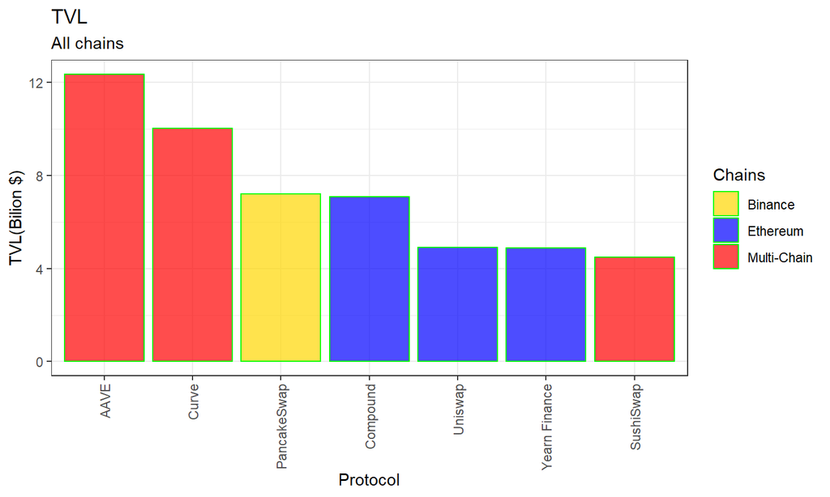

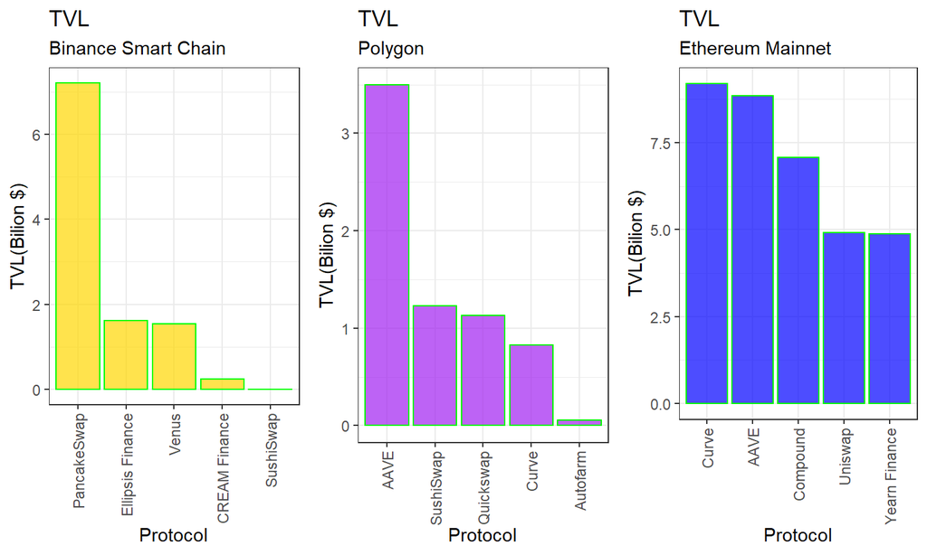

What we observe is that:

- **Ethereum** is the blockchain where most platforms have locked tokens.
- On **Binance Smart Chain**, **PancakeSwap** is the only platform with a comparable TVL.
- **Polygon** is almost used by the same platforms as **Ethereum** (apart from **Quickswap**).

## TVL over time

Analysis of the 5 platforms with higher capitalization, starting from beginning of 2021:

1. AAVE
2. Curve
3. Pancake Swap
4. Compound
5. Uniswap

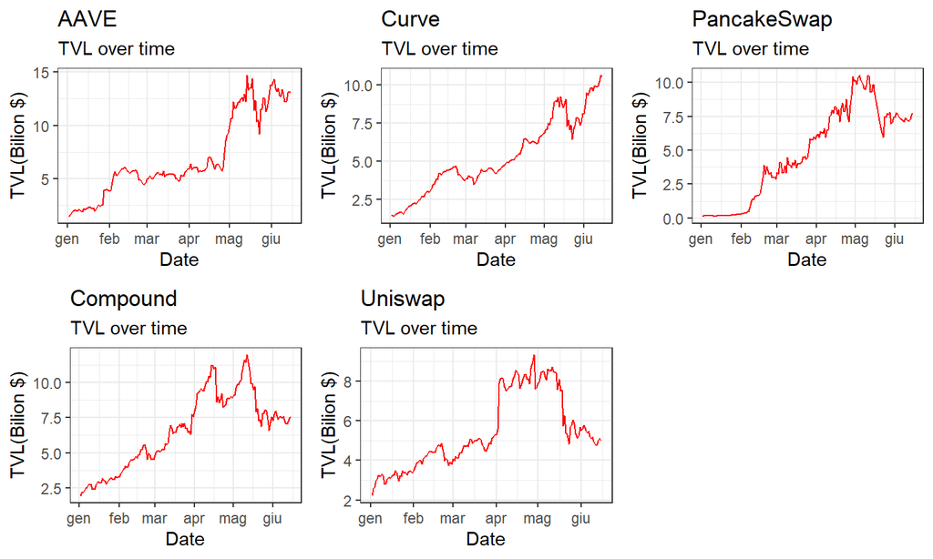

- Similar pattern in the **TVL**: is there a **common factor** affecting **TVL**?

## TVL vs ETH

we compare the TVL with the price of **Ether(ETH)**, the token on which most of our platforms are based:

> Click [this link](https://fradeca01.shinyapps.io/InteractiveTVL/) for an interactive plot.

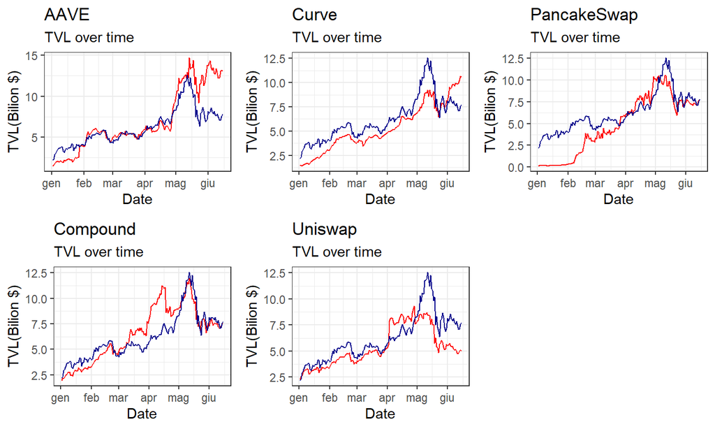

- Correlation between **TVL** and **ETH**

Scatter plot with **TVL** against **ETH Price**:

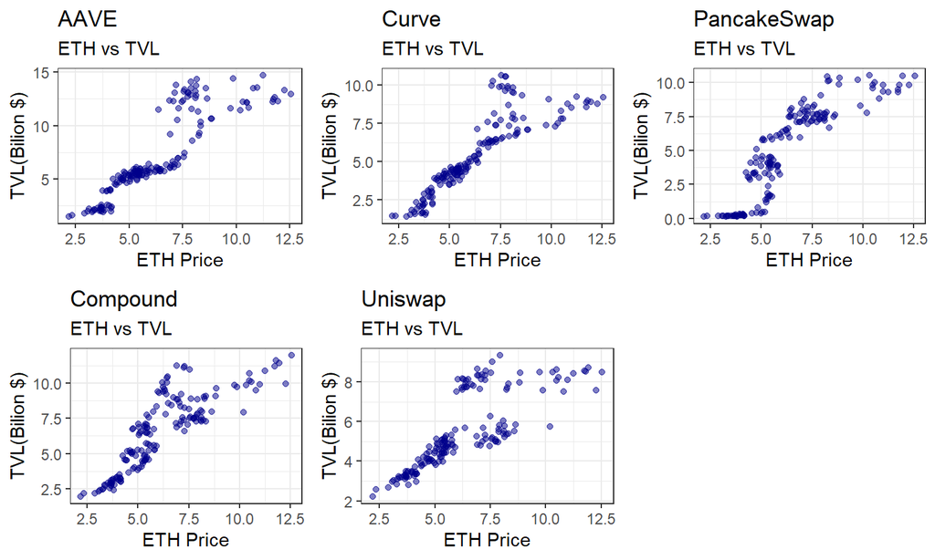

## Modelling

Now, we build a model for each platform, assuming a linear relation:

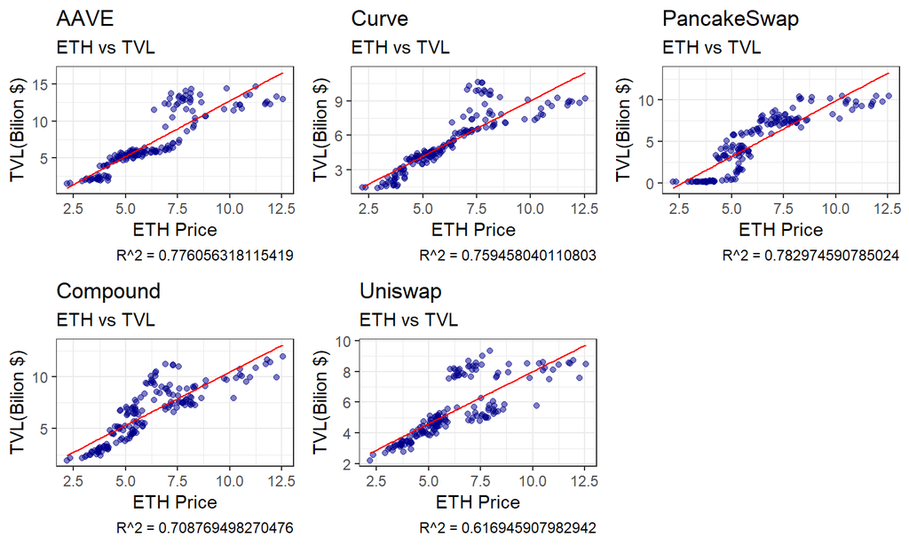

```
##        AAVE       Curve PancakeSwap    Compound     Uniswap
##   0.7760563   0.7594580   0.7829746   0.7087695   0.6169459
```

## Pancake Swap

**PancakeSwap** is developed on the **Binance Smart Chain** and it does not have **ETH** as main token; why the correlation with **ETH** is good anyway?

Model of **PancakeSwap** **TVL** with **BNB Price**:

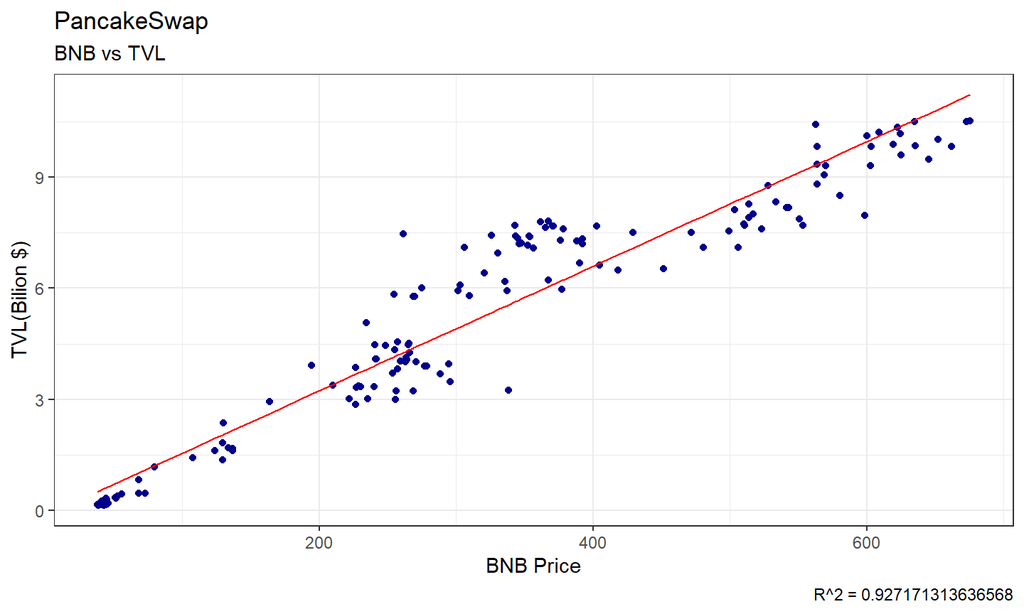

In any case we can analyze **deposits** and **withdrawals** of users through the study of the residuals. We obtain the following plot:

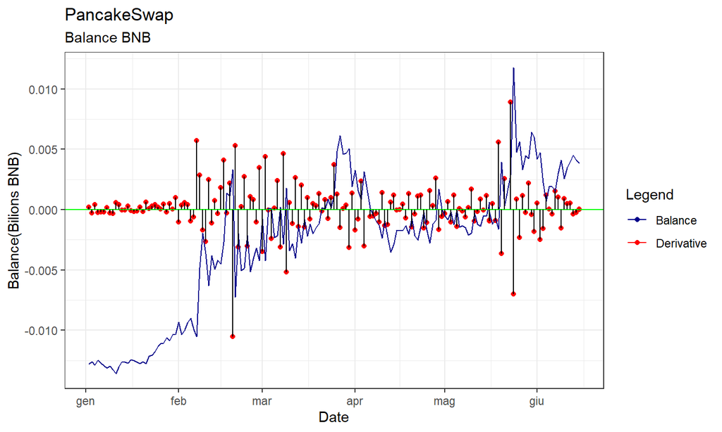

## TVL is not so good as a metric

As we have seen, the **TVL** is hugely influenced by the price of the main token of the blockchain.

It’s not a good indicator of the popularity of a **DeFi Application**, as we can see in this plot:

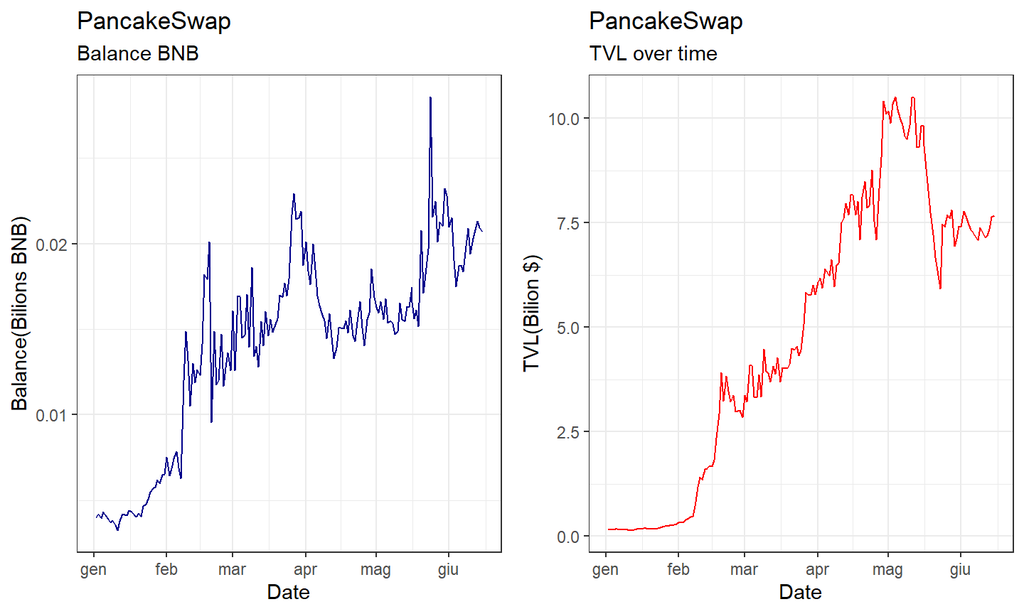

The **patterns** are very different!

## PancakeSwap APR

What is **APR**?

> The **APR(Annual Percentage Rate)** represents the yield obtained from staking funds on a certain pool (without considering the composability).

It’s calculated with the following formula (as we can see [here](https://github.com/pancakeswap/pancake-frontend/blob/develop/src/utils/apr.ts)):

\[ \small APR = \text{CAKES PER YEAR}\times \frac{\text{POOL WEIGHT}}{\text{TOTAL LIQUIDITY}} \times \text{CAKE PRICE} \] Considering that **CAKES PER YEAR** and **POOL WEIGHT** are constants we could rewrite the formula as:

\[ \small APR = k\,\,\frac{\text{CAKE PRICE}}{\text{TOTAL LIQUIDITY}} \] In the above slides we see that the **TVL** of **PancakeSwap** is approximately proportional to the price of **BNB**, this yield:

\[ \small APR \,\propto \,\frac{CAKE}{BNB} \]

## CAKE vs BNB

Is there a correlation between **CAKE** and **BNB** prices?

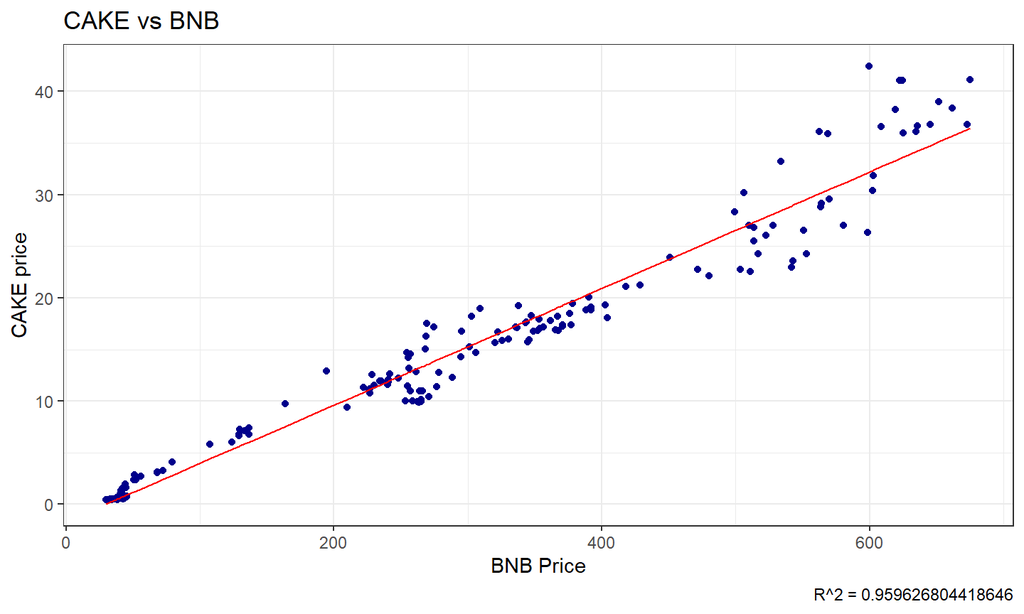

The **BNB** price and the **CAKE** price has been strongly correlated during last year, i.e. \(\small CAKE =k\, BNB\). Plugging this result in last formula we obtain that the **APR** should has been approximately constant.

\[ APR = K \]

## APR is actually costant?

Let’s verify this, plotting the **APR** of some **PancakeSwap** pools:

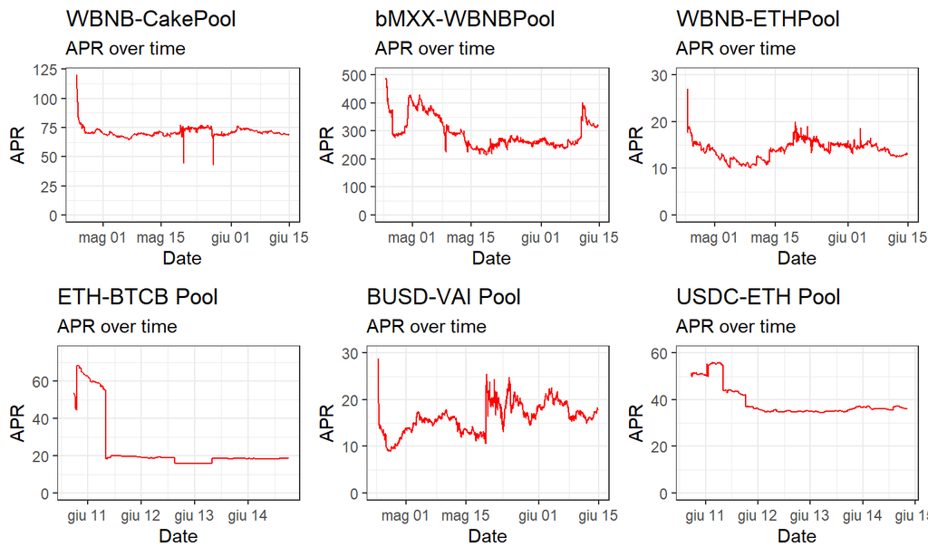

## Future studies

In this study we have seen that **PancakeSwap** liquidity mining program is projected in the way that the **APR** remains as constant as possible during time. This result comes mainly from the fact that:

\[ \small TVL \propto \text{CHAIN TOKEN} \]

We can use this relation for other analysis.

An example is the standard **liquidity pool** reward for staking funds on a pool.

Study of how **APR** of standard **liquidity pools** evolves in time.